# 1 Module 1: Logistic Regression Fundamentals

# 2 Logistic Regression Fundamentals

## 2.1 Learning outcomes

- Identify research questions suited to logistic regression.
- Understang the ‘Generalized Linear Model’ framework, and how this extends linear regression.
- Explain how probabilities map to odds and the logit scale.
- Fit a basic logistic regression in R and generate predictions.

## 2.2 When to use logistic regression

Linear regression is a powerful tool for modelling *continuous* outcomes (blood pressure, weight, test scores). But what if your outcome is *categorical*?

Logistic regression is used when the response variable is binary (0/1, yes/no, success/fail). It models the probability of an event while keeping predictions between 0 and 1.

**Key-point 1**

Logistic regression models the log-odds of an event as a linear function of predictors, then converts back to probability.

**Assumption 1**

Observations are independent, the outcome is binary, and the log-odds are approximately linear in the predictors.

### 2.2.1 A simple example

In `mtcars`, the variable `am` indicates transmission type (0 = automatic, 1 = manual).

```r
table(mtcars$am)
```

```
 0  1
19 13
```

```r
prop.table(table(mtcars$am))
```

```
      0       1
0.59375 0.40625
```

- Continue

## 2.3 From probability to odds and logit

If $p$ is the probability of an event, the odds are
$$\text{odds} = \frac{p}{1 - p}$$
The logit is the log of the odds:
$$\text{logit}(p) = \log\left(\frac{p}{1 - p}\right)$$

```r
p <- 0.2
odds <- p / (1 - p)
logit <- log(odds)
c(p = p, odds = odds, logit = logit)
```

```
        p      odds     logit
 0.200000  0.250000 -1.386294
```

**Note 1**

A change of 1 unit in the logit scale multiplies the odds by about 2.72 (because $e^1 \approx 2.72$).

## 2.4 The logistic curve

The logit scale is linear, but the probability scale is S-shaped. This is why logistic regression keeps predicted probabilities in the 0 to 1 range.

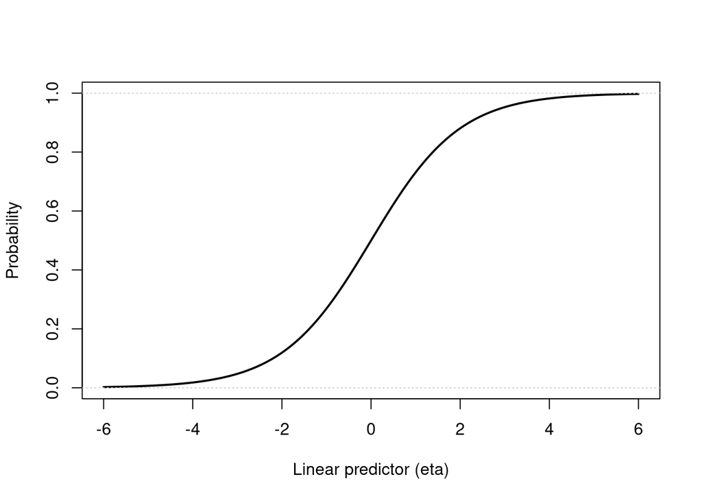

```r
eta <- seq(-6, 6, length.out = 200)
plot(eta, plogis(eta), type = "l", lwd = 2,
     xlab = "Linear predictor (eta)", ylab = "Probability")
abline(h = c(0, 1), col = "grey80", lty = 3)
```

- Continue

## 2.5 Fit your first model in R

```r
fit <- glm(am ~ wt, data = mtcars, family = binomial)
summary(fit)
```

```
Call:
glm(formula = am ~ wt, family = binomial, data = mtcars)

Coefficients:
            Estimate Std. Error z value Pr(>|z|)
(Intercept)   12.040      4.510   2.670  0.00759 **
wt            -4.024      1.436  -2.801  0.00509 **
---
Signif. codes:  0 '***' 0.001 '**' 0.01 '*' 0.05 '.' 0.1 ' ' 1

(Dispersion parameter for binomial family taken to be 1)

    Null deviance: 43.230  on 31  degrees of freedom
Residual deviance: 19.176  on 30  degrees of freedom
AIC: 23.176

Number of Fisher Scoring iterations: 6
```

The model estimates how car weight relates to the log-odds of a manual transmission.

## 2.6 Predicted probabilities

```r
new_cars <- data.frame(wt = c(2.2, 3.0, 3.8))
predict(fit, newdata = new_cars, type = "response")
```

```
         1          2          3
0.96036633 0.49211561 0.03730116
```

**Key-point 2**

`type = "response"` returns predicted probabilities, not log-odds.

## 2.7 Practice prompts

- Interpret the sign of the `wt` coefficient in one sentence.
- Predict the probability of a manual transmission for a car weighing 3.2.
- Fit the model with `hp` as the predictor instead of `wt`. How does the fit change?